```r
library(percolate)
```

- **1f.** Before you go any future, write a few sentences are why it was useful / why you think it will be use to have the `board`’s superclass be `matrix`. (If you have the general idea you can write this after you do the next question.). If you are having struggles thinking about why it’s useful, try doing `t(board_example)` and `board_example[1,2]`.

Using matrix as the superclass allows us to index the board and perform basic operations on the board as if it were a matrix. If not treating it as a matrix, we would not really be able to perform operations on the board in a convenient manner.

# Running experiments

- **3a.** Hopefully now, your `percolate.board()` function is bug-free! The time `percolate.board()` takes to complete scales with `n` and `p`, the size of the board and the percentage of blocked squares. We can time our algorithm using the `system.time()` function. For example, if we wanted to know how fast our algorithm can perform matrix multiplication, we can compute the following.

  ```r
  n <- 500
  system.time(matrix(rnorm(n^2), n, n) %*% matrix(rnorm(n^2), n, n))
  ```

  ```
  ##    user  system elapsed
  ##   0.100   0.002   0.103
  ```

  The `elapsed` number is the total time that has passed. We can extract this number in the following way. (This number might be slightly different from above since we’re running two separate instances of matrix multiplication.)

  ```r
  system.time(matrix(rnorm(n^2), n, n) %*% matrix(rnorm(n^2), n, n))[3]
  ```

  ```
  ## elapsed
  ##   0.099
  ```

  For `p = 0.4`, run 10 trials for each value of `n` from `10` to `100` with spacing of `10`. For each trial, generate a random board using `board(...)`. Then, record the elapsed time to compute whether or not the board percolates using `percolate()`. That is, there will be a total of `10*10 = 100` times `percolate()` will be called. After all the trials are completed, compute average elapsed time for each `n`. (Hint: Writing this set of simulations as an `sapply()` might make your life easier.) (Note: This function might take a while to run, so it’s highly encouraged to fully debug your code beforehand and use coding practices you learned Week 5 when doing this.)

  Then, make a line plot of elapsed time verses `n^2`. Label your plot appropriately. After inspecting your graph, does it seem like your algorithm’s elapsed time (often called the complexity of the algorithm) linear with `n^2`? (For students more comfortable with CS theory: you can try other values of `n` and change your x-axis to other terms such as `n^2*log(n)` if needed.)

  **Approach 2/3:** save your homework file in whatever directory you’d like.

  **Approach 2:** remove the `eval = F` in the following code and replace the `...` with the path to your project (do global path for be safe). Make this string of the directory contains a “/” at the end of it. This should load all your functions in (I’m assuming your haven’t been putting your code in 2 places).

  ```r
  source("https://raw.githubusercontent.com/benjaminleroy/36-350-summer-data/master/Week5/load_my_files_function.R")
  load_my_files(...)
  ```

  **Approach 3:** remove the `eval = F` in the following code and replace the `...` with the path to your project (do global path for be safe).

  ```r
  devtools::load_all(path = "/Users/sohankumar/percolate")
  ```

  ```
  ## Loading percolate
  ```

```r
p <- 0.4
all_times <- vector(length = 10)
times <- vector(length = 10)
for (n in seq(10,100, 10)) {
  for (i in 1:10) {
    test_board <- board(n = n, p = p)
    times[i] <- system.time(percolate.board(test_board))
  }
  all_times[n/10] <- times
}
```

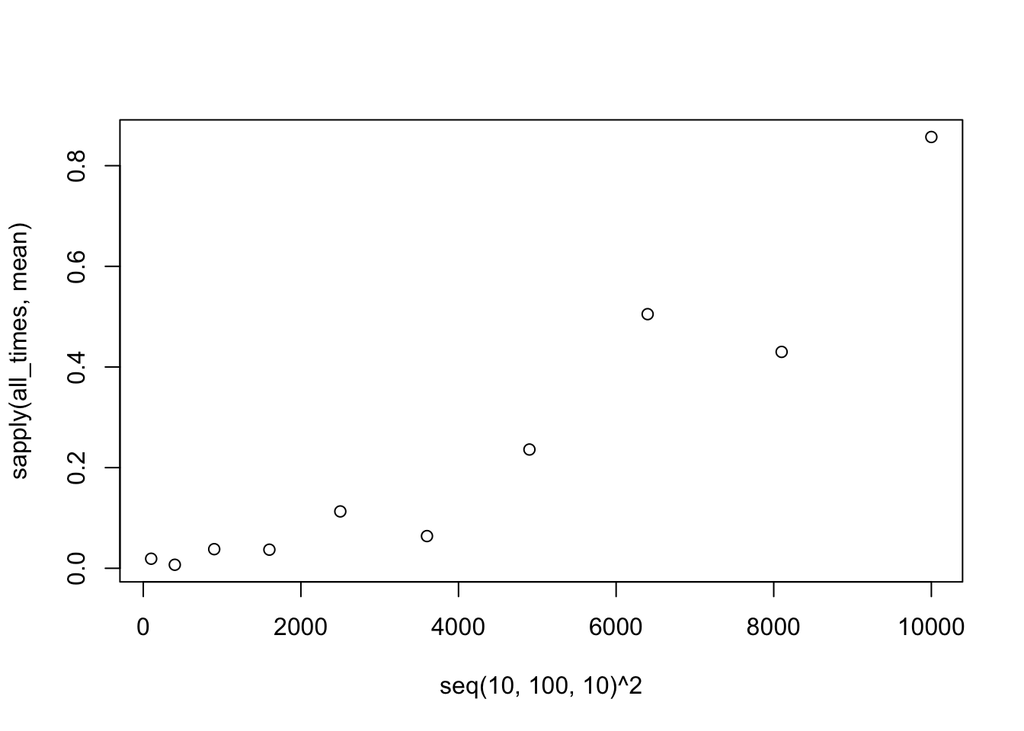

```r
plot(x = seq(10,100,10)^2, y = sapply(all_times, mean))
```

Looks somewhat linear, but with clear outliers.

- **3c.** We now want to see how the fraction of blocked sites `p` affects whether or not a board is likely to percolate. For `n = 5`, `n = 10` and `n = 25`, run 20 trials of each value of `p` from `0` to `1` with spacing of `0.05` (i.e, 21 different values of `p`). For each trial, generate a board using `board(...)` and determine if it percolates using `percolate()`. Among the 20 trials for each setting of `n` and `p`, record the percentage of boards that percolated.

  That is, there will be a total of `20*21*3 = 1260` times `percolate()` will be called.

  Then plot 3 curves (one for each setting of `n`), all on the same plot, of percentage of boards that percolated verses the value of `p` (using only a single data.frame - think back to `dplyr` and `tidyr`). The curves should be a black line for `n = 5`, red for `n = 10` and blue for `n = 25`. Add appropriate axes labels and a legend.

  After inspecting your graph, do you notice a “phase transition” effect where a small change in `p` results in a large change in the probability of percolation? Roughly what value of `p` do you estimate this value to be, and how do you think it relates to `n`?

```r
n_vals <- c(5, 10, 25)
nseq <- c(rep(5, 420), rep(10,420), rep(25,420))
pseq <- c(rep(seq(0,1,0.05), 60))
averages <- vector()
for (n in n_vals) {
  for (p in seq(0,1,0.05)) {
    tests <- vector(length = 20)
    for (i in 1:20) {
      test_board <- board(n=n, p=p)
      tests[i] <- percolate.board(test_board)$result
    }
    averages <- cbind(averages, (sum(tests) / 20) * 100)
  }
}
times_df <- data.frame(n = nseq, p = pseq, average = matrix(averages, nrow=1260, ncol=1))
```

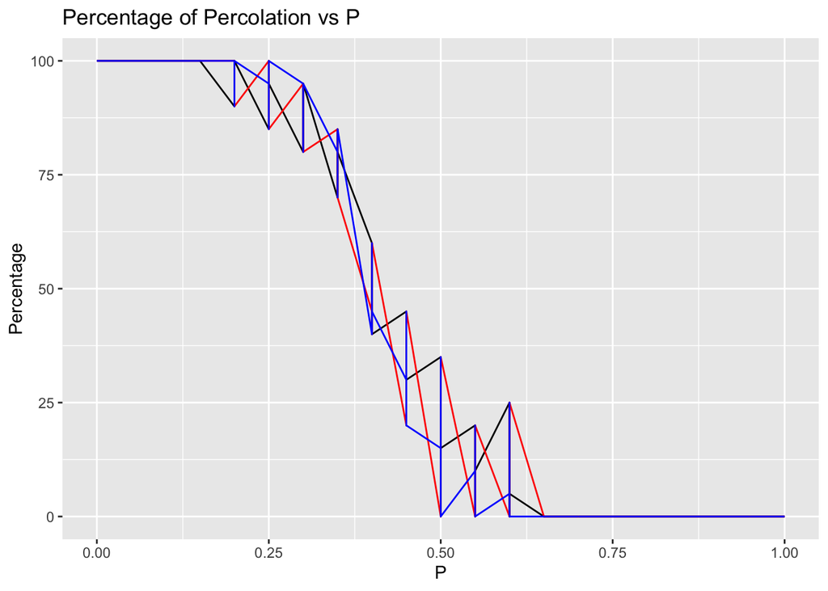

```r
library(ggplot2)
library(dplyr)
ggplot() + geom_line(data=filter(times_df, n == 5), aes(x = p, y = average)) + geom_line(data=filter(times_df, n == 10), aes(x = p, y = average), color="red") + geom_line(data=filter(times_df, n == 25), aes(x = p, y = average), color="blue") +
  labs(title = "Percentage of Percolation vs P",
       x = "P",
       y = "Percentage")
```

Seems like after p=0.25, the probability of percolation decreases drastically.

- **4d.** As the last question, let’s end with a pretty graphic to use all our functions. Read the board (50 by 50) from https://raw.githubusercontent.com/benjaminleroy/36-350-summer-data/master/Week5/percolation_write_large.txt using `read_boards()`. Then, use the percolate the board using `percolate.board()`. Finally, plot the board before percolation and after percolation (similar to the examples in the Introduction) using `plot.board()`. (Hint: You’ll need to use `grid.arrange(...,ncol = 2)`.)

```r
library(gridExtra)
```

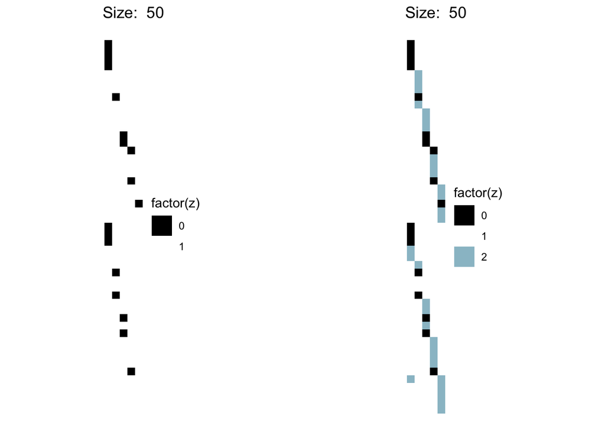

```r
large_board <- read_boards("https://raw.githubusercontent.com/benjaminleroy/36-350-summer-data/master/Week5/percolation_write_large.txt")
percolated_large_board <- percolate.board(large_board[[1]])
grid.arrange(plot_board(large_board[[1]]), plot_board(percolated_large_board[[1]]), ncol =2)
```